# Display and extract seafloor climage change data for Argentina EEZ

Chih-Lin Wei

2024-07-15

```r
library(ArgentinaSSP126)
library(ggplot2)
library(dplyr)
library(patchwork)
library(tidyr)
library(RColorBrewer)
```

In this analysis, we want to extract and display the seafloor climate change data for [Argentina EEZ](https://marineregions.org/gazetteer.php?p=details&id=8466). We can do that by mask the [etopo2022](https://www.ncei.noaa.gov/products/etopo-global-relief-model) raster with Argentina EEZ. We can see that the Argentina EEZ consisting of continental shelf (0-200 m) and continental slope (200-4000 m).

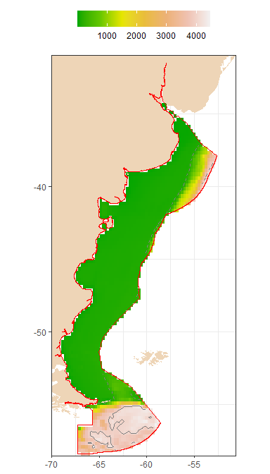

```r
bathy <- etopo2022  %>% mask(eez) %>% as.data.frame(xy = TRUE) %>% na.omit
ggplot(bathy) +
      geom_raster(aes(x=x, y=y, fill=-layer))+
      geom_polygon(data=arg, aes(x=X, y=Y, group=PID), fill="bisque2", colour="transparent")+
      geom_polygon(data=fortify(eez), aes(x=long, y=lat, group=id), fill="transparent", colour="red")+
      geom_contour(data=bathy, aes(x=x, y=y, z=layer), breaks=-200, linetype=2, colour="gray50")+
      geom_contour(data=bathy, aes(x=x, y=y, z=layer), breaks=-4000, linetype=1, colour="gray50")+
      scale_fill_gradientn(colours=terrain.colors(7))+
      scale_x_continuous(expand = expansion(mult = 0))+
      scale_y_continuous(expand = expansion(mult = 0))+
      labs(x=NULL, y=NULL, fill=NULL)+
      coord_fixed(1.52)+
      theme_bw() %+replace% theme(legend.position = "top", legend.key.width =  unit(1, 'cm'))
```

We can use the same [ggplot](https://ggplot2.tidyverse.org/) wrap function to generate multi-panel plots. The custom plot function use the same three parameters, including: + r: A rasterbrick containing the data. + colours: A vector of colors to use for the color key. + limits: A numeric vector of length two providing quantile limits for the color key scale.

```r
plot_fun <- function(r, colours=NULL, q_limits=c(0.001, 0.999)){

  # Convert raster to data frame and then to list
  cmip6_list <- as.data.frame(r, xy = TRUE) %>% na.omit %>%
  gather(-x, -y, key = "var", value = "value") %>%
  group_split(var)

  # Depth
  bathy <- mask(etopo2022, eez)%>% as.data.frame(xy = TRUE) %>% na.omit

  # ggolot list
  gg_list = lapply(cmip6_list, function(dat) {

    # Color key limits and colours
    lim1 <- quantile(dat$value, q_limits, na.rm=TRUE)
    lim2 <- max(abs(quantile(dat$value, q_limits, na.rm=TRUE)))
    if(min(lim1) >= 0) {
      lims <- lim1; cols <- jet.colors(7)
    } else {
      lims <- c(-lim2, lim2); cols <- jet.colors3(7)}
    if(is.null(colours)) cols <- cols else cols <- colours

    # Plot raster layer
    ggplot(dat) +
      geom_raster(aes(x=x, y=y, fill=value))+
      geom_polygon(data=arg, aes(x=X, y=Y, group=PID), fill="bisque2", colour="transparent")+
      geom_polygon(data=fortify(eez), aes(x=long, y=lat, group=id), fill="transparent", colour="red")+
      geom_contour(data=bathy, aes(x=x, y=y, z=layer), breaks=-200, linetype=2, colour="gray50")+
      geom_contour(data=bathy, aes(x=x, y=y, z=layer), breaks=-4000, linetype=1, colour="gray50")+
      scale_fill_gradientn(colours=cols, limits=lims)+
      scale_x_continuous(expand = expansion(mult = 0))+
      scale_y_continuous(expand = expansion(mult = 0))+
      labs(x=NULL, y=NULL, fill=NULL)+
      coord_fixed(1.52)+
      facet_wrap(~ var) +
      theme_bw() %+replace% theme(legend.position = "top", legend.key.width =  unit(1, 'cm'))
      })

  # Wrap ggplot list
  wrap_plots(gg_list, nrow=1)
}
```

For example, we can mask the climate change hazards between 2041 and 2060 by the Argentina EEZ polygon. The following maps show the degree of climate change (or climate change hazards) by 2041 to 2060 in the unit of historical variability during 1951 to 2000.

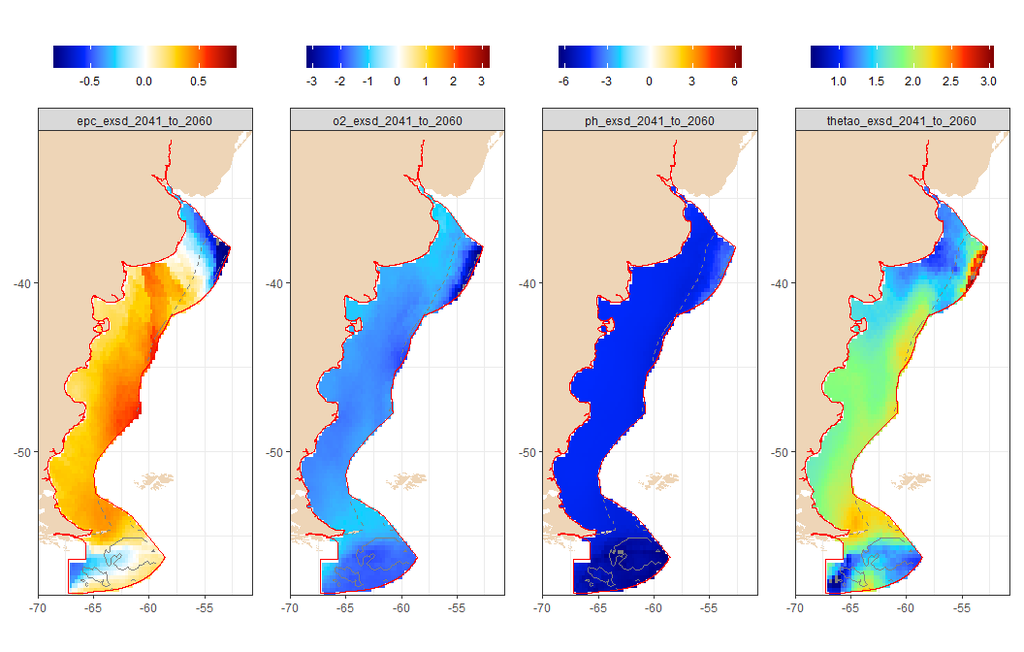

```r
plot_fun(r=cmip6_2041_2060_exsd %>% subset(1:4) %>% mask(eez))
```

We can also use violin plots to show climate change hazards within Argentina EEZ separated by 200-m depth contour (i.e., continental shelf vs. slope).

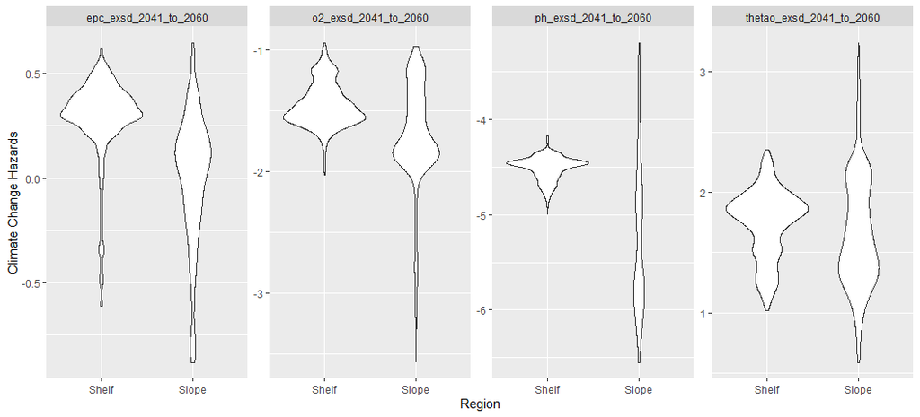

```r
out <- addLayer(etopo2022, cmip6_2041_2060_exsd %>% subset(1:4)) %>% mask(eez) %>% as.data.frame(xy = TRUE) %>% na.omit
out$Region <- cut(-out$layer, c(0, 200, 5000), labels=c("Shelf", "Slope"))

ggplot(data=out %>% gather(-x, -y, -layer, -Region, key = "var", value = "value"))+
  geom_violin(aes(x=Region, y=value))+
  facet_wrap(~var, scales="free", nrow=1)+
  labs(y="Climate Change Hazards")
```

The following maps and violin plots illustrate when climate changes exceed two times the historical standard deviation (or the year when the value of climate change hazards > 2). We use two times the standard deviation because in a roughly normal data set, values within one standard deviation of the mean account for about 68% of the set, while values within two standard deviations account for about 95%.

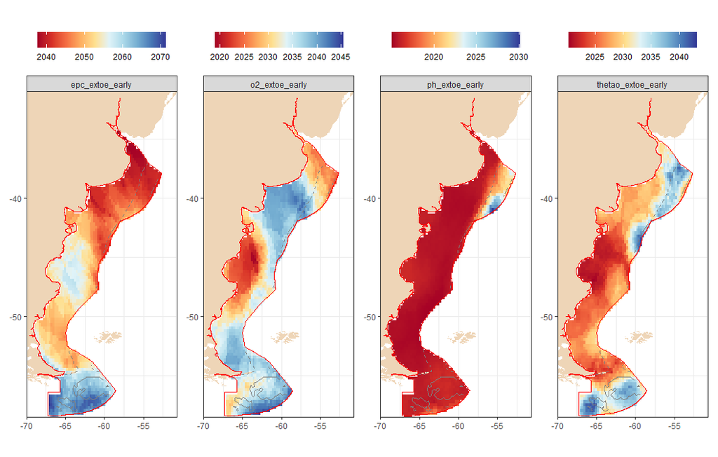

```r
plot_fun(cmip6_extoe_early %>% subset(1:4) %>% mask(eez), colours = brewer.pal(10, 'RdYlBu'), q_limits = c(0, 1))
```

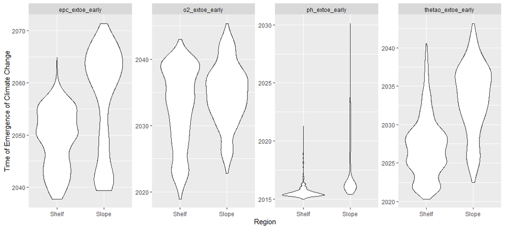

```r
out <- addLayer(etopo2022, cmip6_extoe_early %>% subset(1:4)) %>% mask(eez) %>% as.data.frame(xy = TRUE) %>% na.omit
out$Region <- cut(-out$layer, c(0, 200, 5000), labels=c("Shelf", "Slope"))

ggplot(data=out %>% gather(-x, -y, -layer, -Region, key = "var", value = "value"))+
  geom_violin(aes(x=Region, y=value))+
  facet_wrap(~var, scales="free", nrow=1)+
  labs(y="Time of Emergence of Climate Change")
```

Next, we show the years when climate changes for export POC flux, dissolved oxygen, pH, and temperature simultaneously exceed twice the historical variability.

```r
all <- overlay(subset(cmip6_extoe_early, 1:4), fun=max) %>% mask(eez) %>% as.data.frame(xy = TRUE) %>% na.omit
bathy <- etopo2022 %>% mask(eez) %>% as.data.frame(xy = TRUE) %>% na.omit
p1 <- ggplot(all) +
      geom_raster(aes(x=x, y=y, fill=layer))+
      geom_polygon(data=arg, aes(x=X, y=Y, group=PID), fill="bisque2", colour="transparent")+
      geom_polygon(data=fortify(eez), aes(x=long, y=lat, group=id), fill="transparent", colour="red")+
      geom_contour(data=bathy, aes(x=x, y=y, z=layer), breaks=-200, linetype=2, colour="gray50")+
      geom_contour(data=bathy, aes(x=x, y=y, z=layer), breaks=-4000, linetype=1, colour="gray50")+
      scale_fill_gradientn(colours=brewer.pal(10, 'RdYlBu'))+
      scale_x_continuous(expand = expansion(mult = 0))+
      scale_y_continuous(expand = expansion(mult = 0))+
      labs(x=NULL, y=NULL, fill=NULL)+
      coord_fixed(1.52)+
      theme_bw() %+replace% theme(legend.position = "right", legend.key.height =  unit(1.8, 'cm'))

# Violin plots
out <- addLayer(etopo2022, overlay(subset(cmip6_extoe_early, 1:4), fun=max)) %>% mask(eez) %>% as.data.frame(xy = TRUE) %>% na.omit
out$Region <- cut(-out$layer.1, c(0, 200, 5000), labels=c("Shelf", "Slope"))

p2 <- ggplot(data=out)+
  geom_violin(aes(x=Region, y=layer.2))+
  labs(y="Time of Emergence of Climate Change")
```

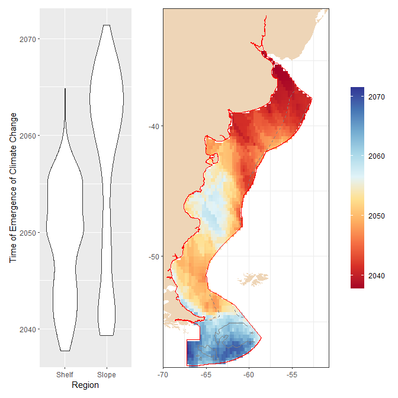

```r
p2+p1+plot_layout(widths = c(1, 2))
```

Another application involves calculating the cumulative impacts of climate change hazards. The negative hazards are caused by declining export POC flux, deoxygenation, ocean acidification, and ocean warming. The positive impacts are increasing export POC flux, oxygenation, ocean basification, and ocean cooling. Here, we use the same function to calculate cumulative negative and positive impacts caused by climate change hazards.

```r
cum_imp <- function(r){
  # Negative cumulative impact (exposure to climate change hazards for epc<0, o2<0, ph<0, and thetao>0)
  n2050 <- addLayer(calc(subset(r, 1:3), fun=function(x){x[x>0]<-NA; return(-x)}),
                    calc(subset(r, 4), fun=function(x){x[x<0]<-NA; return(x)})
                    ) %>%　overlay(fun=function(x)sum(x, na.rm=T))

  # Positive cumulative impact (exposure to climate change hazards for epc>0, o2>0, ph>0, and thetao<0)
  p2050 <- addLayer(calc(subset(r, 1:3), fun=function(x){x[x<0]<-NA; return(x)}),
                    calc(subset(r, 4), fun=function(x){x[x>0]<-NA; return(-x)})
                    ) %>%　overlay(fun=function(x)sum(x, na.rm=T))

  out <- addLayer(n2050, p2050)
  names(out) <- c("Negative", "Positive")
  out <- mask(out, etopo2022)
  return(out)
}
```

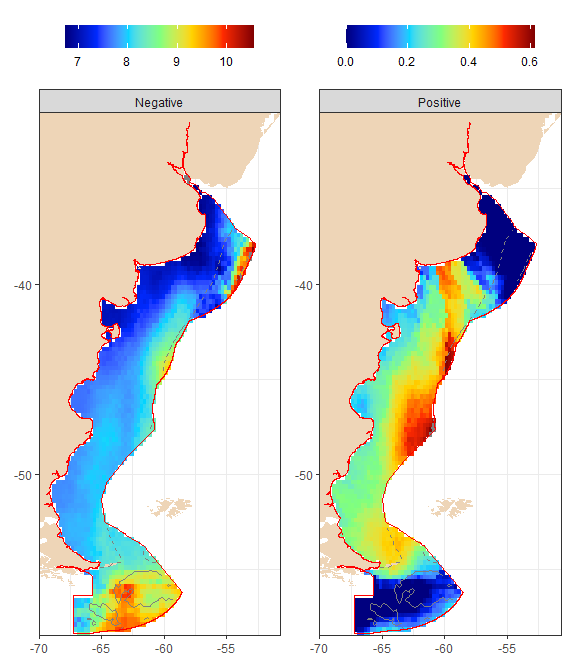

```r
plot_fun(r=cum_imp(cmip6_2041_2060_exsd) %>% mask(eez))
```

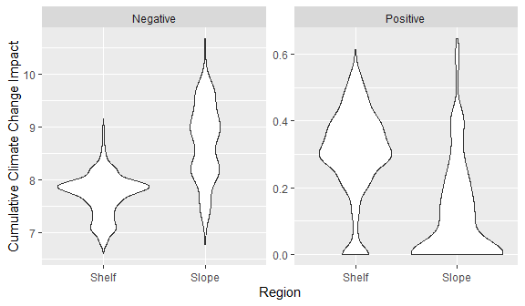

```r
out <- addLayer(etopo2022, cum_imp(cmip6_2041_2060_exsd)) %>% mask(eez) %>% as.data.frame(xy = TRUE) %>% na.omit
out$Region <- cut(-out$layer, c(0, 200, 5000), labels=c("Shelf", "Slope"))

ggplot(data=out %>% gather(-x, -y, -layer, -Region, key = "var", value = "value"))+
  geom_violin(aes(x=Region, y=value))+
  facet_wrap(~var, scales="free")+
  labs(y="Cumulative Climate Change Impact")
```

An important factor for the survival of species is how quickly they need to move to adjust to current environmental conditions and keep up with climate changes. Local climate velocity can be calculated by measuring the rate of change of a specific variable (like temperature) over time and dividing it by the corresponding spatial gradient of that variable within a 3x3 area. Areas with low local climate velocities may be good candidates for protection, as they could potentially act as climatic refuges and are often associated with high levels of endemic species. It’s important to note that in deep seafloor environments, like the abyssal plain, the spatial gradient may be small, resulting in high climate velocities. In our example, we display the average seafloor gradient-based climate velocity magnitudes from 2041 to 2060 within Argentina EEZ.

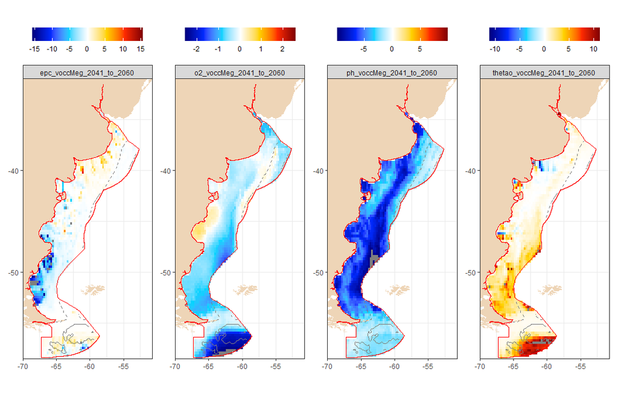

```r
plot_fun(cmip6_2041_2060_voccMeg %>% subset(1:4) %>% mask(eez), q_limits=c(0.01, 0.99))
```

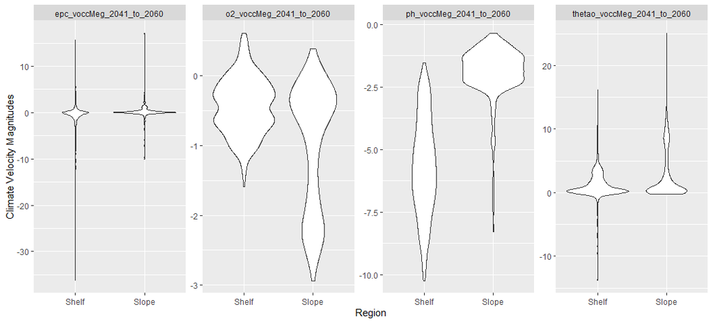

```r
out <- addLayer(etopo2022, cmip6_2041_2060_voccMeg %>% subset(1:4)) %>% mask(eez) %>% as.data.frame(xy = TRUE) %>% na.omit
out$Region <- cut(-out$layer, c(0, 200, 5000), labels=c("Shelf", "Slope"))

ggplot(data=out %>% gather(-x, -y, -layer, -Region, key = "var", value = "value"))+
  geom_violin(aes(x=Region, y=value))+
  facet_wrap(~var, scales="free", nrow=1)+
  labs(y="Climate Velocity Magnitudes")
```

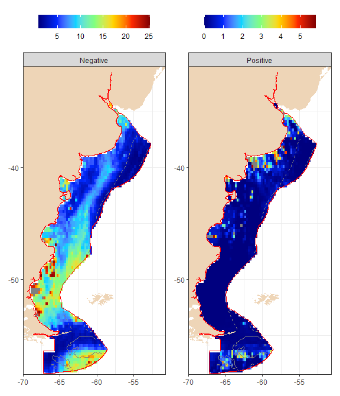

```r
plot_fun(r=cum_imp(cmip6_2041_2060_voccMeg) %>% mask(eez), q_limits = c(0, 0.99))
```

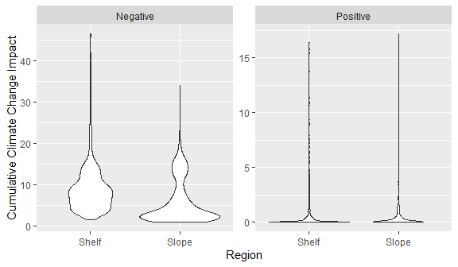

```r
out <- addLayer(etopo2022, cum_imp(cmip6_2041_2060_voccMeg)) %>% mask(eez) %>% as.data.frame(xy = TRUE) %>% na.omit
out$Region <- cut(-out$layer, c(0, 200, 5000), labels=c("Shelf", "Slope"))

ggplot(data=out %>% gather(-x, -y, -layer, -Region, key = "var", value = "value"))+
  geom_violin(aes(x=Region, y=value))+
  facet_wrap(~var, scales="free")+
  labs(y="Cumulative Climate Change Impact")
```